# Coursework Report

[output not shown]

**Main analysis results**

[interactive chart not shown]

[figure not shown]

[interactive chart not shown]

# Coursework Report

Analysing Data, Spring 2020

# Methods

## Participants

The experiment was initially taken by 150 female undergraduates in the United States who volunteered to participant in return for credit on their courses. When completed 38 participants were removed: 27 were removed for ethical reasons as they were under 18, 6 were removed for being an improbable age over 100 (possibly due to a typo), and 5 removed for having NA’s in their data (mostly age). The remaining number of participants was 112. Participants who remained had mean age = 20.9, sd = 1.62 with min = 19 and max = 26.

Table 1 *Descriptive Statistics by Experiment Group*

| GROUP | N | % | *M*<sub>age</sub> | *SD*<sub>age</sub> |
| --- | --- | --- | --- | --- |
| control | 55 | 49.11 | 20.96 | 1.75 |
| experimental | 57 | 50.89 | 20.88 | 1.50 |

Table 2 *Descriptive statistics by group and ratings of questions*

[output not shown]

## Design

This experiment investigated the effect of colour manipulation between the colour red and white on a woman’s perceived attraction to a man. Results are expected to show a higher mean in perceived attractiveness ratings from women viewing the red bordered photograph than females viewing the white bordered photograph.

In the experiment, participants were shown a 4-by-6-inch, black-and-white photograph of a man for 5 seconds. This photograph showed a Caucasian male with brown hair wearing a plan button-down shirt centred on an 8.5-by-11-inch page. The control group saw this photograph of a man centred on white background (with the background just being an absence of colour), while the experimental group saw this photograph centred on a red page. White was chosen as a control as it is a neutral colour so as not to obstruct the experimental paradigm.

After looking at the photograph for 5 seconds participants were then measured on their perceived attractiveness of the man in the picture on a 9-point rating scale from 1 (not at all attractive) to 9 (extremely attractive). This was operationalised through 3 questions: “How attractive do you think this person is?”, “How pleasant is this person to look at?” and “If I were to meet the person in this picture face to face, I would think he is attractive”.

Scores were then averaged to construct a composite score, and with the composite score, an independent two-sided t-test was run between attraction and experimental group.

# Results

```
##
##  Two Sample t-test
##
## data:  questions_comp by GROUP
## t = -3.7218, df = 110, p-value = 0.0003135
## alternative hypothesis: true difference in means is not equal to 0
## 95 percent confidence interval:
##  -0.9152455 -0.2792255
## sample estimates:
##      mean in group control mean in group experimental
##                   5.812121                   6.409357
```

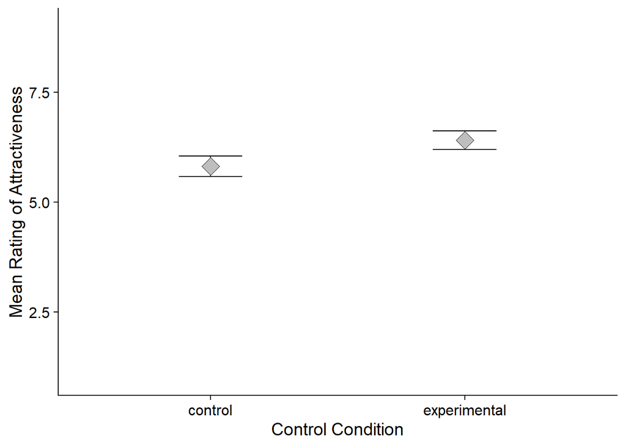

# Discussion

The results of this experiment showed that woman perceive men to be more attractive and pleasant to look at if they were seen on a red background, than if seen with a white background showing a red-attraction link. An independent t-test also confirms that these results are significant are not from the same population thus reason to accept the alternative hypothesis that colour does influence participant ratings of attractiveness.

This conclusion is similar to the original study which produced similar results, although with a wider gap between perceived attractiveness between the two groups than my results. Production of similar results points to the reliability of the original experiment. As the operationalisation of “perceived attractiveness” was three very simple questions directly related to the concept of perceived attractiveness the ratings directly measure what is being studied. These results serve to further support that the colour red not only has romantic and sexual connotations for men to women, but also from women to men.

The next paragraph will describe the connotations of red in societal conditions and its relevance to this current study and potential future study. Colour is often seen as having societal contexts which stretch beyond aesthetic carrying denotative connotations of meaning and substance (Peperkoon, Roberts & Pollet, 2016). This effect is often automatic and not largely a conscious process. Kaspar, Grummer, Kiebler, Neub and Schroter (2015) reported that the colour red increased participant “attentional engagement” when observing angry and happy human faces, in comparison to neutral expressions. The attention bias to red is seen throughout human history. Archaic societies have been shown to paint holy objects in red to emphasise importance and value; In eastern-Asian cultures and sub-Saharan Africa, red is seen as a symbol of wealth and prominence even often being worn by brides to weddings (Elliot et al., 2010). This connotation of red is even present in religion: Ravid (1992) reported how Jews in ancient Rome would don red headdresses to distinguish themselves from others while the Christian church in the late 12th century utilized this same concept as Jesuits (catholics closest to the pope) wear red (Elliot et al., 2010). In modern day red objects such as red ties and red carpets are assigned to special days and reserved for notable individuals. Even more evident in modern day, is the association of the colour red in modern day media with female sexuality for example: red lipstick, The Scarlet Letter and the red-light districts (Elliot, Tracy, Padza and Beall, 2013; Elliot & Padza, 2016). Given this bare-faced connotation of the colour red and sexuality, particularly female, whether this link is made for male sexuality it a point worth discussing. If this red-attraction link indeed shows a basic, fundamental link in human psychology it should be seen universality. Contemporary research has focused on one-way modes of attraction and been operated mainly in the United States and Europe. Further research into potential similarities and nuances between culture, region and race could potential point to a physiological-based association or a societal association for both male to female attraction and female to male – either of which is worth investigation. Physiological basis reveals further information on the human psyche while societal association has several anthropological implications (i.e. marketing).

This experiment shows this lacks in external validity. While the original study has some diversity 66% of the participants are Caucasian, and my data set does not show ethnicity. Without scaling for cultural, ethnical and even regional differences this study cannot be applied to populations at large. Its ecological validity can also be questioned. Potentially also, is the connotations of white. If there are any societal connotations of white is red the only variable affecting results? If not these results may be invalid. As this experiment was completed in a lab, its external validity can be questioned. Hesslinger, Golbach and Carbon (2015) completed this test but instead of testing participants individually, they tested them as a whole group. Results showed that the red-attraction association was not as robust as Elliot et al. (2010) has reported, and as my results also showed. While this does suggest that the red-attraction link may work in some situations and others, Elliot et al.’s (2010) testing of participants individually may be the best method in showing individualistic attraction without the influence of other participants bias of the model based on clothing, race or otherwise.

While research on male-female-attraction in red is well researched, further research should be poured in female-to-male attractions. As well as this, attention should be paid to racial effects – is this effect still the same when participants are looking at black, Asian or Latino men. Is this effect still the same when the male in the photograph is wearing clothes which are contrary to red connotations of wealth and high status? Is this effect reduced or increased based on individual’s socioeconomic status? Research into these differences can prove useful in properly defining this concept. To conclude, the main findings of my study support the original study that women do perceive men to be more attractive when perceived with a red background over a white background. While the ecological and external validity of this experiment can be questioned the operationalisation of the variables is solid and valid. Further research into the red-attraction link over several dimensions such ethnicity, race, region and socioeconomic status will strengthen this hypothesis.

# References

Elliot, A., Niesta Kayser, D., Greitemeyer, T., Lichtenfeld, S., Gramzow, R., Maier, M., & Liu, H. (2010). Red, rank, and romance in women viewing men. Journal Of Experimental Psychology: General, 139(3), 399-417. doi: 10.1037/a0019689

Elliot, A., Tracy, J., Pazda, A., & Beall, A. (2013). Red enhances women’s attractiveness to men: First evidence suggesting universality. Journal Of Experimental Social Psychology, 49(1), 165-168. doi: 10.1016/j.jesp.2012.07.017

Hesslinger, V., Goldbach, L., & Carbon, C. (2015). Men in red: A reexamination of the red-attractiveness effect. Psychonomic Bulletin & Review, 22(4), 1142-1148. doi: 10.3758/s13423-015-0866-8

Kaspar, K., Grümmer, M., Kießler, A., Neuß, C., & Schröter, F. (2015). The effects of colour and valence on news evaluation. International Journal Of Psychology, 52(6), 491-498. doi: 10.1002/ijop.12234

Pazda, A., & Elliot, A. (2016). Processing the Word Red can Enhance Women’s Perceptions of Men’s Attractiveness. Current Psychology, 36(2), 316-323. doi: 10.1007/s12144-016-9420-8

Peperkoorn, L., Roberts, S., & Pollet, T. (2016). Revisiting the Red Effect on Attractiveness and Sexual Receptivity. Evolutionary Psychology, 14(4), 147470491667384. doi: 10.1177/1474704916673841

Ravid, B. From yellow to red: On the distinguishing head-covering of the Jews of Venice. Jew History 6, 179–210 (1992). https://doi-org.ezproxy.sussex.ac.uk/10.1007/BF01695218